# Ejemplo modelos de conteo

- Show All Code
- Hide All Code

Aida Calviño - Junio 2025

# Tareas iniciales: librerías y datos

Comenzamos cargando las librerías que vamos a necesitar:

**Mostrar el código**

```r
library(caret)
library(AER)
library(purrr)
library(dplyr)
library(MASS)
# Para paralelizar
library(doParallel)
cluster <- makeCluster(detectCores() - 1)
registerDoParallel(cluster)
```

Continuamos leyendo los datos depurados y haciendo un *str* para verificar que los tipos de las variables han sido asignados correctamente (numéricas para las cuantitativas y factor para las cualitativas). Así mismo, hacemos un *summary* para ver si los datos tienen errores y/o datos ausentes, pero no es así:

**Mostrar el código**

```r
datos<-readRDS("DatosEjemploConteo")
str(datos)
```

```
'data.frame':   2078 obs. of  11 variables:
 $ Genero        : Factor w/ 2 levels "Female","Male": 2 1 1 1 1 1 2 2 1 1 ...
 $ Edad          : num  14 15 16 16 16 16 16 16 16 16 ...
 $ IMC           : num  24.6 31.6 19.9 25.6 25.7 22.3 17.9 21.4 14.3 31.4 ...
 $ Pareja        : Factor w/ 2 levels "no","yes": 2 2 1 2 2 1 2 2 1 2 ...
 $ ComidaCalorica: Factor w/ 2 levels "No","Yes": 2 2 1 2 2 2 1 1 2 2 ...
 $ CentroDep     : Factor w/ 3 levels "1","2","3": 1 1 2 2 2 1 2 2 1 1 ...
 $ NumeroComidas : Factor w/ 4 levels "1","2","3","4": 2 1 3 1 3 4 1 1 1 4 ...
 $ Alcohol       : Factor w/ 2 levels "no","yes": 1 1 2 1 1 1 1 2 2 1 ...
 $ ActFisica     : num  3 5 0 2 2 7 1 3 4 3 ...
 $ ClaseSocial   : Factor w/ 3 levels "Alta","Media",..: 1 3 2 2 2 3 1 2 2 3 ...
 $ Parque        : Factor w/ 2 levels "Si","No": 2 2 2 2 2 2 2 2 2 2 ...
```

**Mostrar el código**

```r
summary(datos)
```

```
    Genero          Edad            IMC        Pareja     ComidaCalorica
 Female:1029   Min.   :14.00   Min.   :13.00   no : 381   No : 291
 Male  :1049   1st Qu.:20.00   1st Qu.:24.30   yes:1697   Yes:1787
               Median :23.00   Median :28.70
               Mean   :24.33   Mean   :29.69
               3rd Qu.:26.00   3rd Qu.:36.00
               Max.   :61.00   Max.   :50.80
 CentroDep NumeroComidas Alcohol      ActFisica    ClaseSocial  Parque
 1:982     1:491         no : 633   Min.   :0.00   Alta : 506   Si: 239
 2:994     2:516         yes:1445   1st Qu.:0.00   Media:1095   No:1839
 3:102     3:509                    Median :1.00   Baja : 477
           4:562                    Mean   :1.62
                                    3rd Qu.:3.00
                                    Max.   :7.00
```

Para facilitar la comprensión de este documento, se incluye a continuación una tabla con la descripción de las variables independientes:

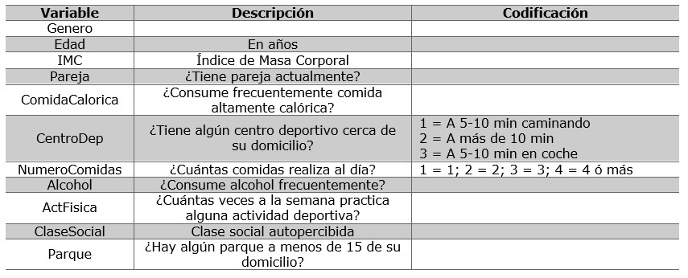

En este caso, la variable dependiente que queremos modelizar es *ActFisica*; la cual recoge información sobre el número de veces a la semana que se realiza algún tipo de actividad física/deportiva. Se trata de una variable discreta (o de conteo), por lo que el tipo de modelo que tendremos que aplicar es el *Poisson*. Como en ocasiones anteriores, comenzamos visualizando la variable y los valores que toma:

**Mostrar el código**

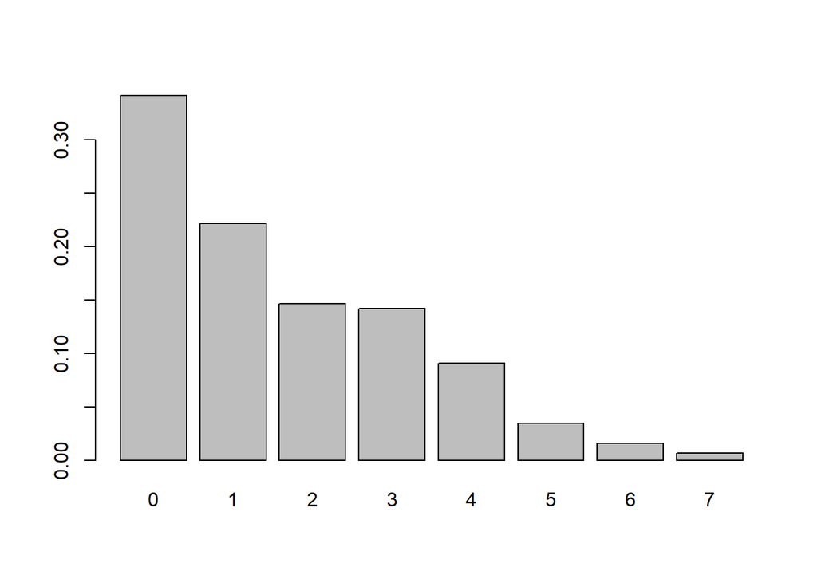

```r
barplot(table(datos$ActFisica)/nrow(datos))
```

Como podemos observar, la mayor parte de las observaciones se asocian con personas que no realizan ningún tipo de actividad física (aproximadamente un 35%). Las frecuencias van disminuyendo hasta el valor máximo de 7. Revisando los resultados del *summary()* anterior, vemos que el valor medio es 1.62 y la mediana, 1.

# Creación de modelos de regresión *Poisson*

Antes de comenzar a construir los propios modelos vamos a proceder a realizar la división entrenamiento-prueba para poder así contar con un subconjunto de datos diferente sobre el que poder evaluar el modelo y obtener así estimaciones de calidad más fiables. Para ello, utilizamos la función *createDataPartition*, asignando el 80% de los datos a entrenamiento y el 20% restante a prueba:

**Mostrar el código**

```r
set.seed(12345)
trainIndex <- createDataPartition(datos$ActFisica, p=0.8, list=FALSE)
data_train <- datos[trainIndex,]
data_test <- datos[-trainIndex,]
```

A continuación vamos a construir un primer modelo de regresión *Poisson* utilizando todas las variables independientes disponibles. Para ello, recurrimos a la función *glm* indicando que la familia es *poisson* (se trata de la misma función que en el modelo de regresión logística binaria). Debemos indicarle así mismo la fórmula de la regresión, es decir, las variables independientes y la dependiente; así como el conjunto de datos:

**Mostrar el código**

```r
modeloInicial <- glm(ActFisica ~ ., data=data_train, family=poisson)
modeloInicial$rank #para contar el número de parámetros
```

```
[1] 15
```

**Mostrar el código**

```r
summary(modeloInicial)
```

```
Call:
glm(formula = ActFisica ~ ., family = poisson, data = data_train)

Coefficients:
                    Estimate Std. Error z value Pr(>|z|)
(Intercept)        1.5837402  0.1158612  13.669  < 2e-16 ***
GeneroMale         0.4416694  0.0418852  10.545  < 2e-16 ***
Edad              -0.0127396  0.0034075  -3.739 0.000185 ***
IMC               -0.0195962  0.0031905  -6.142 8.14e-10 ***
Parejayes         -0.0130668  0.0561040  -0.233 0.815837
ComidaCaloricaYes  0.0945496  0.0610147   1.550 0.121233
CentroDep2        -0.2296506  0.0416045  -5.520 3.39e-08 ***
CentroDep3        -0.2001989  0.0962801  -2.079 0.037586 *
NumeroComidas2     0.0682273  0.0550707   1.239 0.215381
NumeroComidas3     0.0005394  0.0557875   0.010 0.992285
NumeroComidas4    -0.0305481  0.0551088  -0.554 0.579357
Alcoholyes        -0.2194791  0.0418526  -5.244 1.57e-07 ***
ClaseSocialMedia  -0.1297230  0.0450419  -2.880 0.003976 **
ClaseSocialBaja   -0.4729028  0.0605997  -7.804 6.01e-15 ***
ParqueNo          -0.1414319  0.0580030  -2.438 0.014754 *
---
Signif. codes:  0 '***' 0.001 '**' 0.01 '*' 0.05 '.' 0.1 ' ' 1

(Dispersion parameter for poisson family taken to be 1)

    Null deviance: 3154.4  on 1663  degrees of freedom
Residual deviance: 2810.1  on 1649  degrees of freedom
AIC: 5751.9

Number of Fisher Scoring iterations: 5
```

Como ocurre con un gran número de funciones en R, la llamada a la función no genera ninguna salida, por lo que debemos recurrir a la función *summary* para poder visualizar las componentes del modelo.

En la salida anterior podemos observar el valor de cada uno de los parámetros estimados (que son 15), junto con sus errores estándar y p-valores, la *residual deviance* y el AIC del modelo. Con la información anterior, podemos ver que sólo hay 5 parámetros no significativos, aunque esta conclusión no es definitiva pues habrá que verificar que no existe un problema de sobredispersión y que, por ende, no hay más parámetros no significativos.

Para poder continuar con el análisis de este modelo, vamos a verificar si existe sobredispersión. Para ello, vamos a recurrir al test de dispersión de la librería *AER*, que contrasta si deberían multiplicarse los errores estándar de los parámetros por un coeficiente estrictamente mayor que uno:

**Mostrar el código**

```r
dispersiontest(modeloInicial)
```

```
    Overdispersion test

data:  modeloInicial
z = 12.212, p-value < 2.2e-16
alternative hypothesis: true dispersion is greater than 1
sample estimates:
dispersion
  1.535032
```

El contraste indica que, a cualquier nivel de significación razonable, se debe rechazar la hipótesis nula y asumir la hipótesis alternativa de que el factor de corrección es mayor que 1, es decir, en estos datos hay sobredispersión y, por ende, un modelo *Poisson* no es adecuado.

**A pesar de que no es lo idóneo para estos datos, mostramos a continuación los pasos a seguir para la construcción, análisis y evaluación del modelo para aquellos casos en los que no exista un problema de sobredispersión.**

Tal y como se ha hecho con el resto de modelos, se puede aplicar el análisis de tipo II para estudiar la significatividad de las variables (no de sus parámetros) y obtener una ordenación de la utilidad de las variables teniendo en cuenta la reducción en la verosimilitud que tiene lugar al eliminar cada una de las variables:

**Mostrar el código**

```r
Anova(modeloInicial, type = "II")
```

```
Analysis of Deviance Table (Type II tests)

Response: ActFisica
               LR Chisq Df Pr(>Chisq)
Genero          113.682  1  < 2.2e-16 ***
Edad             14.611  1  0.0001321 ***
IMC              37.687  1  8.305e-10 ***
Pareja            0.054  1  0.8159638
ComidaCalorica    2.437  1  0.1184840
CentroDep        31.090  2  1.774e-07 ***
NumeroComidas     3.654  3  0.3013612
Alcohol          27.035  1  1.998e-07 ***
ClaseSocial      65.545  2  5.848e-15 ***
Parque            5.779  1  0.0162169 *
---
Signif. codes:  0 '***' 0.001 '**' 0.01 '*' 0.05 '.' 0.1 ' ' 1
```

Como hemos podido observar, hay 3 variables que no son significativas al 5% (Pareja, ComidaCalorica y NumeroComidas). Así mismo, vemos que las variables más importantes son el género y la clase social.

Con fines ilustrativos vamos a construir un modelo sólo con las tres variables más importantes (se trata de una decisión pedagógica para ilustrar de manera más compacta cómo se interpretan los coeficientes de los modelos):

**Mostrar el código**

```r
modelo2<-glm(ActFisica ~ Genero+ClaseSocial+IMC, data=data_train, family=poisson)
summary(modelo2)
```

```
Call:
glm(formula = ActFisica ~ Genero + ClaseSocial + IMC, family = poisson,
    data = data_train)

Coefficients:
                  Estimate Std. Error z value Pr(>|z|)
(Intercept)       1.149310   0.088550  12.979  < 2e-16 ***
GeneroMale        0.376035   0.039935   9.416  < 2e-16 ***
ClaseSocialMedia -0.148082   0.044642  -3.317  0.00091 ***
ClaseSocialBaja  -0.463169   0.059793  -7.746 9.47e-15 ***
IMC              -0.024192   0.002559  -9.452  < 2e-16 ***
---
Signif. codes:  0 '***' 0.001 '**' 0.01 '*' 0.05 '.' 0.1 ' ' 1

(Dispersion parameter for poisson family taken to be 1)

    Null deviance: 3154.4  on 1663  degrees of freedom
Residual deviance: 2894.7  on 1659  degrees of freedom
AIC: 5816.5

Number of Fisher Scoring iterations: 5
```

Como vemos, se trata de un modelo con 5 parámetros (todos ellos aparentemente significativos) pero con un AIC superior al anterior, por lo que se hace patente que este modelo es demasiado sencillo.

Seguidamente obtenemos las exponenciales de los coeficientes (que se suelen denominar riesgos relativos) del modelo para determinar el efecto de las variables explicativas sobre la dependiente (podemos hacerlo sobre cualquiera de los dos modelos pues los coeficientes no se han modificado):

**Mostrar el código**

```r
exp(coef(modelo2))
```

```
     (Intercept)       GeneroMale ClaseSocialMedia  ClaseSocialBaja
       3.1560146        1.4564980        0.8623608        0.6292861
             IMC
       0.9760978
```

- *Genero*: el riesgo relativo es superior a 1 lo que indica que, en líneas generales, los hombres practican actividad física con mayor asiduidad que las mujeres. Más concretamente, los hombres practican deporte semanalmente un 45% más que las mujeres.
- *ClaseSocial*: en este caso, los riesgos relativos son menores que 1 (además de significativos) por lo que se observa una disminución en la frecuencia deportiva con respecto a la categoría de referencia (alta). En concreto, las personas de clase media practican deporte semanalmente un 14% menos que las de clase alta. Lo mismo ocurre con las personas de clase baja, reduciéndose un 37%.
- *IMC*: en este caso volvemos a obtener un odds-ratio por debajo de 1, por lo que las personas con altos valores del IMC practican deporte un número inferior de veces. En particular, por cada punto adicional del IMC, el número de veces a la semana que se practica actividad física se reduce en un 2.4%.

# Evaluación de modelos de conteo

Para evaluar el modelo, tal y como se vio en la teoría, podemos recurrir al $R^2$, por lo que usamos el mismo código que en el caso de la regresión lineal (lo hacemos en train y test para analizar también la estabilidad):

**Mostrar el código**

```r
R2(predict(modelo2, data_train, type = "response"), data_train$ActFisica)
```

```
[1] 0.09750683
```

**Mostrar el código**

```r
R2(predict(modelo2, data_test, type = "response"), data_test$ActFisica)
```

```
[1] 0.02876037
```

Se puede observar que la calidad del modelo no es muy buena, lo que implica que, aunque hayamos detectado algunos factores que influyen significativamente en la frecuencia de la actividad física, existen otros factores que no estamos capturando.

En términos de $R^2$ el valor en test no alcanza el $3\%$ y se observa poca estabilidad (por la diferencia con *train*).

Del código anterior es importante destacar que a la función *predict()* le pedimos que nos facilite la respuesta pues, de no ponerlo, nos facilitaría únicamente el valor de la combinación lineal de las variables explicativas (sin aplicar la exponencial).

# Métodos automáticos de selección de variables y comparación de modelos de *Poisson*

Dado que el modelo que hemos construido manualmente es demasiado sencillo, seguidamente vamos a obtener otros modelos aplicando los métodos automáticos de selección de variables. Para ello, igual que en los modelos anteriores, recurrimos a la función *step* en la cual podemos modificar la dirección y el estadístico de selección. De nuevo, requiere que construyamos previamente el modelo “mínimo” y el “máximo” (debido a que las salidas son extensas en este proceso, se ha incluido la opción *trace=F* para evitar que se muestre el proceso de creación de los modelos y el documento se alargue de manera innecesaria):

**Mostrar el código**

```r
null<-glm(ActFisica ~ 1, data=data_train, family=poisson)
full<-glm(ActFisica ~ ., data=data_train, family=poisson)
modeloStepBIC<-step(null, scope=list(lower=null, upper=full), direction="both",
                    k=log(nrow(data_train)),trace=F)
modeloStepAIC<-step(null, scope=list(lower=null, upper=full), direction="both",trace=F)
modeloForwBIC<-step(null, scope=list(lower=null, upper=full), direction="forward",
                    k=log(nrow(data_train)),trace=F)
modeloForwAIC<-step(null, scope=list(lower=null, upper=full), direction="forward",trace=F)
modeloBackBIC<-step(full, scope=list(lower=null, upper=full), direction="backward",
                    k=log(nrow(data_train)),trace=F)
modeloBackAIC<-step(full, scope=list(lower=null, upper=full), direction="backward",trace=F)
modelos<-list(modeloStepBIC,modeloStepAIC,modeloForwBIC,modeloForwAIC,modeloBackBIC,
              modeloBackAIC)
map(modelos,function(x) x$call)
```

```
[[1]]
glm(formula = ActFisica ~ Genero + IMC + ClaseSocial + Alcohol +
    CentroDep + Edad, family = poisson, data = data_train)

[[2]]
glm(formula = ActFisica ~ Genero + IMC + ClaseSocial + CentroDep +
    Alcohol + Edad + Parque + ComidaCalorica, family = poisson,
    data = data_train)

[[3]]
glm(formula = ActFisica ~ Genero + IMC + ClaseSocial + Alcohol +
    CentroDep + Edad, family = poisson, data = data_train)

[[4]]
glm(formula = ActFisica ~ Genero + IMC + ClaseSocial + CentroDep +
    Alcohol + Edad + Parque + ComidaCalorica, family = poisson,
    data = data_train)

[[5]]
glm(formula = ActFisica ~ Genero + Edad + IMC + CentroDep + Alcohol +
    ClaseSocial, family = poisson, data = data_train)

[[6]]
glm(formula = ActFisica ~ Genero + Edad + IMC + ComidaCalorica +
    CentroDep + Alcohol + ClaseSocial + Parque, family = poisson,
    data = data_train)
```

**Mostrar el código**

```r
map_int(modelos,function(x) x$rank)
```

```
[1]  9 11  9 11  9 11
```

Como se puede observar, los 6 procesos dan como resultado dos modelos distintos, con 9 y 11 parámetros, respectivamente. Para poder determinar cuál de los modelos es mejor, vamos a recurrir a la validación cruzada repetida, gracias a la cual podremos evaluar los modelos mediante las medidas ya estudiadas. A continuación, creamos una lista que contenga todos los modelos que se deseen comparar (elegimos dos nombres de los 6 creados pues sólo hay dos diferentes) y seguidamente creamos un bucle para recorrer dicha lista y llevar a cabo la validación cruzada repetida. Nótese que para poder construir modelos *Poisson* se ha incluido que el método sea “*glm*” y la familia *poisson*:

**Mostrar el código**

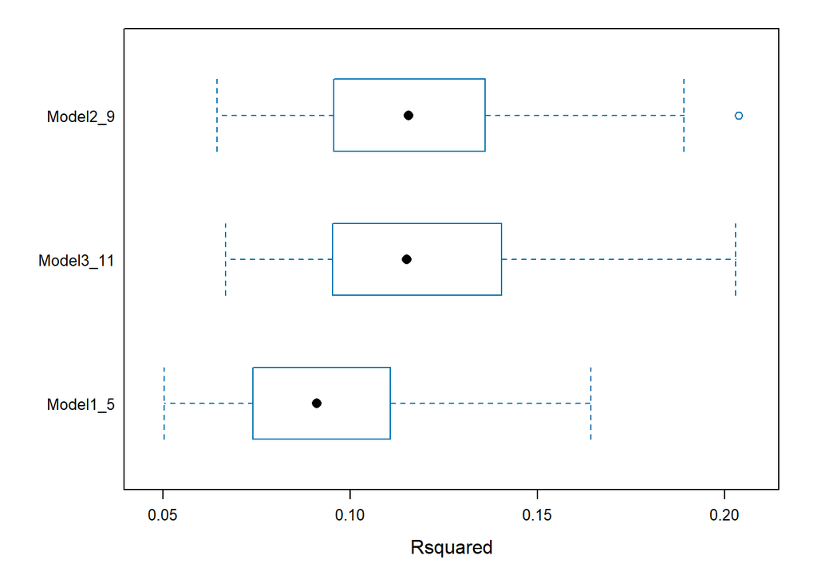

```r
modelos<-list(modelo2,modeloStepBIC,modeloStepAIC)
vcrTodosModelos<-list()
for (i in 1:length(modelos)){
  set.seed(1712)
  vcr <- train (formula(modelos[[i]]),
                data = data_train, method = "glm", family=poisson,
                trControl = trainControl(method = "repeatedcv",
                                         number = 5, repeats=20)
  )
  vcrTodosModelos[[i]]<-vcr
}
names(vcrTodosModelos)<-paste0("Model",1:length(modelos), "_",sapply(modelos,function(x) x$rank))
bwplot(resamples(vcrTodosModelos), scales = list(x = list(relation = "free")),
       metric=c("Rsquared"))
```

**Mostrar el código**

```r
summary(resamples(vcrTodosModelos), metric=c("Rsquared"))
```

```
Call:
summary.resamples(object = resamples(vcrTodosModelos), metric = c("Rsquared"))

Models: Model1_5, Model2_9, Model3_11
Number of resamples: 100

Rsquared
                Min.    1st Qu.     Median       Mean   3rd Qu.      Max. NA's
Model1_5  0.05026418 0.07396756 0.09104544 0.09478563 0.1105967 0.1642109    0
Model2_9  0.06441108 0.09590580 0.11549667 0.11872318 0.1360022 0.2037475    0
Model3_11 0.06662437 0.09546425 0.11504922 0.11904506 0.1402865 0.2029562    0
```

Como se puede observar tanto en los *boxplot* como en el resumen de los valores, el primer modelo es de menor calidad que los otros dos pues presenta valores peores de calidad. Entre el segundo y el tercer modelo apenas hay diferencias (no se aprecian hasta el tercer decimal). Dado que el segundo (el que procede de BIC) tiene dos parámetros menos, consideraremos ese como ganador.

Para finalizar, obtendríamos los correspondientes p-valores (incorrectos en este caso, pero lo hacemos con fines ilustrativos) y riesgos relativos:

**Mostrar el código**

```r
summary(modeloStepBIC)
```

```
Call:
glm(formula = ActFisica ~ Genero + IMC + ClaseSocial + Alcohol +
    CentroDep + Edad, family = poisson, data = data_train)

Coefficients:
                  Estimate Std. Error z value Pr(>|z|)
(Intercept)       1.547057   0.104730  14.772  < 2e-16 ***
GeneroMale        0.438205   0.041199  10.636  < 2e-16 ***
IMC              -0.019674   0.002706  -7.271 3.56e-13 ***
ClaseSocialMedia -0.132325   0.044996  -2.941 0.003273 **
ClaseSocialBaja  -0.478662   0.060134  -7.960 1.72e-15 ***
Alcoholyes       -0.222188   0.041126  -5.403 6.56e-08 ***
CentroDep2       -0.224417   0.041251  -5.440 5.32e-08 ***
CentroDep3       -0.207819   0.096175  -2.161 0.030708 *
Edad             -0.012736   0.003404  -3.742 0.000183 ***
---
Signif. codes:  0 '***' 0.001 '**' 0.01 '*' 0.05 '.' 0.1 ' ' 1

(Dispersion parameter for poisson family taken to be 1)

    Null deviance: 3154.4  on 1663  degrees of freedom
Residual deviance: 2821.4  on 1655  degrees of freedom
AIC: 5751.2

Number of Fisher Scoring iterations: 5
```

**Mostrar el código**

```r
exp(coef(modeloStepBIC))
```

```
     (Intercept)       GeneroMale              IMC ClaseSocialMedia
       4.6976245        1.5499233        0.9805182        0.8760562
 ClaseSocialBaja       Alcoholyes       CentroDep2       CentroDep3
       0.6196119        0.8007645        0.7989822        0.8123542
            Edad
       0.9873450
```

Como podemos ver, todos los parámetros menos serían significativos al 5%. Además, los riesgos relativos asociados a las variables incluidas en el modelo2 se han mantenido prácticamente constantes por lo que no será necesario volverlos a interpretar.

En cuanto a los parámetros restantes, podemos interpretar los siguientes:

- *Edad*: por cada año adicional que tenga una persona, el número de veces que realiza una actividad física semanalmente se reduce un 1.3%.
- *CentroDep2*: aquellas personas que tienen un centro deportivo a más de 10 minutos (ya sea caminando o en coche) realizan actividades deportivas un 20% menos de veces a la semana que las que sí tienen un centro deportivo “cerca”.
- *CentroDep3*: aquellas personas que tienen un centro deportivo a 5-10 minutos en coche realizan actividades deportivas un 20% menos de veces a la semana que aquellas que tienen un centro deportivo a 5-10 minutos caminando.
- *Alcohol*: aquellas personas que consumen alcohol con frecuencia, realizan actividad física un 20% menos de veces a la semana que las que no consumen alcohol.

Para completar el estudio de las variables que componen el modelo, realizamos el análisis de tipo II, detectando que las variables más importantes continúan siendo el género, la clase social y el IMC:

**Mostrar el código**

```r
Anova(modeloStepBIC,type = "II")
```

```
Analysis of Deviance Table (Type II tests)

Response: ActFisica
            LR Chisq Df Pr(>Chisq)
Genero       115.528  1  < 2.2e-16 ***
IMC           53.426  1  2.685e-13 ***
ClaseSocial   68.408  2  1.397e-15 ***
Alcohol       28.669  1  8.587e-08 ***
CentroDep     30.457  2  2.434e-07 ***
Edad          14.635  1  0.0001305 ***
---
Signif. codes:  0 '***' 0.001 '**' 0.01 '*' 0.05 '.' 0.1 ' ' 1
```

Finalizamos este documento mediante las medidas de evaluación del modelo en entrenamiento y prueba:

**Mostrar el código**

```r
R2(predict(modeloStepBIC,data_train,type = "response"), data_train$ActFisica)
```

```
[1] 0.1254125
```

**Mostrar el código**

```r
R2(predict(modeloStepBIC,data_test,type = "response"), data_test$ActFisica)
```

```
[1] 0.05914854
```

Observamos que la calidad continúa siendo mala, a pesar de la mejora observada gracias a la inclusión de tres variables adicionales. Se concluye que el modelo es mejorable pero que se ha conseguido encontrar ciertos factores que sí repercuten en el hecho de realizar actividad física con mayor/menor frecuencia. Se trata de un modelo relativamente estable, lo que reafirma la influencia de las variables explicativas, aunque no tengan una capacidad predictiva fuerte.

# Creación de modelos de regresión *Binomial Negativo*

En presencia de sobredispersión, es preferible optar por construir un modelo *Binomial Negativo*. En estos modelos, la función de enlace es la misma, pero se modifica la hipótesis sobre la distribución de la variable objetivo. Debido a este cambio, estos modelos cuentan con un parámetro adicional (que también se estima por máxima verosimilitud) que recoge dicha sobredispersión.

Para construir estos modelos, recurrimos a la función *glm.nb* de la librería *MASS*:

**Mostrar el código**

```r
modeloInicial_NB<-glm.nb(ActFisica ~ ., data=data_train)
summary(modeloInicial_NB)
```

```
Call:
glm.nb(formula = ActFisica ~ ., data = data_train, init.theta = 2.656597564,
    link = log)

Coefficients:
                   Estimate Std. Error z value Pr(>|z|)
(Intercept)        1.583778   0.151258  10.471  < 2e-16 ***
GeneroMale         0.453340   0.053285   8.508  < 2e-16 ***
Edad              -0.014571   0.004283  -3.402 0.000670 ***
IMC               -0.018414   0.004130  -4.458 8.26e-06 ***
Parejayes         -0.021150   0.073932  -0.286 0.774821
ComidaCaloricaYes  0.084577   0.079525   1.064 0.287546
CentroDep2        -0.226365   0.054456  -4.157 3.23e-05 ***
CentroDep3        -0.189896   0.121727  -1.560 0.118758
NumeroComidas2     0.077400   0.071374   1.084 0.278172
NumeroComidas3     0.008959   0.071757   0.125 0.900642
NumeroComidas4    -0.025908   0.070777  -0.366 0.714325
Alcoholyes        -0.208067   0.054852  -3.793 0.000149 ***
ClaseSocialMedia  -0.110759   0.059289  -1.868 0.061746 .
ClaseSocialBaja   -0.458211   0.076373  -6.000 1.98e-09 ***
ParqueNo          -0.153392   0.076843  -1.996 0.045916 *
---
Signif. codes:  0 '***' 0.001 '**' 0.01 '*' 0.05 '.' 0.1 ' ' 1

(Dispersion parameter for Negative Binomial(2.6566) family taken to be 1)

    Null deviance: 2152.4  on 1663  degrees of freedom
Residual deviance: 1941.0  on 1649  degrees of freedom
AIC: 5595.3

Number of Fisher Scoring iterations: 1

              Theta:  2.657
          Std. Err.:  0.297

 2 x log-likelihood:  -5563.296
```

La salida de este modelo es muy similar al anterior, pero se incluye información sobre el parámetro $\theta$, que recordemos debe tomar valores muy grandes para que se considere que este modelo y el *poisson* son análogos. De todas formas, para comparar los dos modelos, es preferible recurrir a un contraste, como el contraste de razón de verosimilitudes, que evalúe si el aumento en la complejidad de este parámetro adicional, compensa el aumento en la verosimilitud (comparamos los dos modelos “con todo” pues este contraste solo permite comparar modelos anidados):

**Mostrar el código**

```r
lrtest(modeloInicial_NB,modeloInicial)
```

```
Likelihood ratio test

Model 1: ActFisica ~ Genero + Edad + IMC + Pareja + ComidaCalorica + CentroDep +
    NumeroComidas + Alcohol + ClaseSocial + Parque
Model 2: ActFisica ~ Genero + Edad + IMC + Pareja + ComidaCalorica + CentroDep +
    NumeroComidas + Alcohol + ClaseSocial + Parque
  #Df  LogLik Df Chisq Pr(>Chisq)
1  16 -2781.7
2  15 -2860.9 -1 158.6  < 2.2e-16 ***
---
Signif. codes:  0 '***' 0.001 '**' 0.01 '*' 0.05 '.' 0.1 ' ' 1
```

Verificamos que, efectivamente, el modelo NB tiene un parámetro más (16 vs. 15). Así mismo, vemos que el valor del estadístico es grande y el p-valor pequeño, por lo que podemos rechazar la $H_0$ de que los dos modelos son igual de buenos. Queda demostrado que, en este caso, el modelo NB, que es más flexible, es preferible.

Así mismo, si nos fijamos en los p-valores de los contrastes de los parámetros de los modelos completos *Poisson* y *BN*, podemos ver que se ha recogido correctamente esa sobredispersión y algunos parámetros han dejado de ser significativos.

Aplicamos a continuación el análisis de tipo II para estudiar la significatividad de las variables:

**Mostrar el código**

```r
Anova(modeloInicial_NB, type = "II")
```

```
Analysis of Deviance Table (Type II tests)

Response: ActFisica
               LR Chisq Df Pr(>Chisq)
Genero           73.556  1  < 2.2e-16 ***
Edad             12.462  1  0.0004153 ***
IMC              20.788  1  5.130e-06 ***
Pareja            0.082  1  0.7747744
ComidaCalorica    1.144  1  0.2848179
CentroDep        17.805  2  0.0001360 ***
NumeroComidas     2.431  3  0.4878514
Alcohol          14.314  1  0.0001547 ***
ClaseSocial      38.905  2  3.563e-09 ***
Parque            3.932  1  0.0473832 *
---
Signif. codes:  0 '***' 0.001 '**' 0.01 '*' 0.05 '.' 0.1 ' ' 1
```

Probamos a construir un modelo con las 3 variables más importantes:

**Mostrar el código**

```r
modelo2_NB<-glm.nb(ActFisica ~ Genero+ClaseSocial+IMC, data=data_train)
modelo2_NB$rank
```

```
[1] 5
```

**Mostrar el código**

```r
summary(modelo2_NB)
```

```
Call:
glm.nb(formula = ActFisica ~ Genero + ClaseSocial + IMC, data = data_train,
    init.theta = 2.378650287, link = log)

Coefficients:
                  Estimate Std. Error z value Pr(>|z|)
(Intercept)       1.089730   0.117021   9.312  < 2e-16 ***
GeneroMale        0.380964   0.051559   7.389 1.48e-13 ***
ClaseSocialMedia -0.131474   0.059981  -2.192   0.0284 *
ClaseSocialBaja  -0.451539   0.076488  -5.903 3.56e-09 ***
IMC              -0.022622   0.003304  -6.848 7.51e-12 ***
---
Signif. codes:  0 '***' 0.001 '**' 0.01 '*' 0.05 '.' 0.1 ' ' 1

(Dispersion parameter for Negative Binomial(2.3787) family taken to be 1)

    Null deviance: 2083.8  on 1663  degrees of freedom
Residual deviance: 1932.2  on 1659  degrees of freedom
AIC: 5627.2

Number of Fisher Scoring iterations: 1

              Theta:  2.379
          Std. Err.:  0.248

 2 x log-likelihood:  -5615.153
```

# Métodos automáticos de selección de variables y comparación de modelos de *Binomial Negativo*

Como en modelo anteriores, estudiamos a continuación cómo aplicar métodos automáticos de selección de variables. Para ello, de nuevo recurrimos a la función *step* en la cual podemos modificar la dirección y el estadístico de selección. De nuevo, requiere que construyamos previamente el modelo “mínimo” y el “máximo” (debido a que las salidas son extensas en este proceso, se ha incluido la opción *trace=F* para evitar que se muestre el proceso de creación de los modelos y el documento se alargue de manera innecesaria):

**Mostrar el código**

```r
null<-glm.nb(ActFisica ~ 1, data=data_train)
full<-glm.nb(ActFisica ~ ., data=data_train)
modeloStepBIC<-step(null, scope=list(lower=null, upper=full), direction="both",
                    k=log(nrow(data_train)),trace=F)
modeloStepAIC<-step(null, scope=list(lower=null, upper=full), direction="both",trace=F)
modeloForwBIC<-step(null, scope=list(lower=null, upper=full), direction="forward",
                    k=log(nrow(data_train)),trace=F)
modeloForwAIC<-step(null, scope=list(lower=null, upper=full), direction="forward",trace=F)
modeloBackBIC<-step(full, scope=list(lower=null, upper=full), direction="backward",
                    k=log(nrow(data_train)),trace=F)
modeloBackAIC<-step(full, scope=list(lower=null, upper=full), direction="backward",trace=F)
modelos<-list(modeloStepBIC,modeloStepAIC,modeloForwBIC,modeloForwAIC,modeloBackBIC,
              modeloBackAIC)
map(modelos,function(x) x$call)
```

```
[[1]]
glm.nb(formula = ActFisica ~ Genero + IMC + ClaseSocial + Edad +
    Alcohol + CentroDep, data = data_train, init.theta = 2.617334837,
    link = log)

[[2]]
glm.nb(formula = ActFisica ~ Genero + IMC + ClaseSocial + CentroDep +
    Alcohol + Edad + Parque, data = data_train, init.theta = 2.634166636,
    link = log)

[[3]]
glm.nb(formula = ActFisica ~ Genero + IMC + ClaseSocial + Edad +
    Alcohol + CentroDep, data = data_train, init.theta = 2.617334837,
    link = log)

[[4]]
glm.nb(formula = ActFisica ~ Genero + IMC + ClaseSocial + CentroDep +
    Alcohol + Edad + Parque, data = data_train, init.theta = 2.634166636,
    link = log)

[[5]]
glm.nb(formula = ActFisica ~ Genero + Edad + IMC + CentroDep +
    Alcohol + ClaseSocial, data = data_train, init.theta = 2.617334837,
    link = log)

[[6]]
glm.nb(formula = ActFisica ~ Genero + Edad + IMC + CentroDep +
    Alcohol + ClaseSocial + Parque, data = data_train, init.theta = 2.634166636,
    link = log)
```

**Mostrar el código**

```r
map_int(modelos,function(x) x$rank)
```

```
[1]  9 10  9 10  9 10
```

**Mostrar el código**

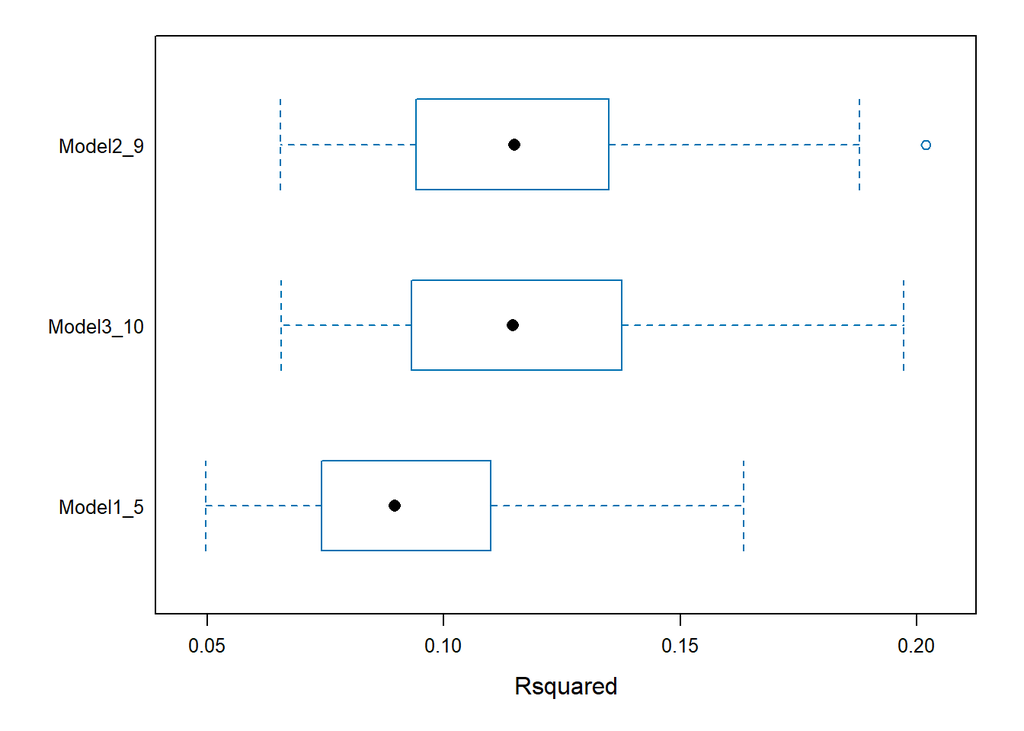

```r
modelos<-list(modelo2_NB,modeloStepBIC,modeloStepAIC)
vcrTodosModelos<-list()
coefIniModelos<-sapply(modelos,coef)
for (i in 1:length(modelos)){
  set.seed(1712)
  vcr <- train (formula(modelos[[i]]), data = data_train,
                method = "glm.nb", start=coefIniModelos[[i]],
                trControl = trainControl(method = "repeatedcv",
                                         number = 5, repeats=20)
  )
  vcrTodosModelos[[i]]<-vcr
}
names(vcrTodosModelos)<-paste0("Model",1:length(modelos), "_",sapply(modelos,function(x) x$rank))
bwplot(resamples(vcrTodosModelos), scales = list(x = list(relation = "free")),
       metric=c("Rsquared"))
```

**Mostrar el código**

```r
summary(resamples(vcrTodosModelos), metric=c("Rsquared"))
```

```
Call:
summary.resamples(object = resamples(vcrTodosModelos), metric = c("Rsquared"))

Models: Model1_5, Model2_9, Model3_10
Number of resamples: 100

Rsquared
                Min.    1st Qu.     Median       Mean   3rd Qu.      Max. NA's
Model1_5  0.04973137 0.07442582 0.08969576 0.09395661 0.1098427 0.1633849    0
Model2_9  0.06545222 0.09424590 0.11495046 0.11789562 0.1347997 0.2019250    0
Model3_10 0.06576457 0.09329819 0.11460879 0.11787248 0.1376362 0.1973013    0
```

Para finalizar, obtenemos los correspondientes p-valores y riesgos relativos:

**Mostrar el código**

```r
summary(modeloStepBIC)
```

```
Call:
glm.nb(formula = ActFisica ~ Genero + IMC + ClaseSocial + Edad +
    Alcohol + CentroDep, data = data_train, init.theta = 2.617334837,
    link = log)

Coefficients:
                  Estimate Std. Error z value Pr(>|z|)
(Intercept)       1.546989   0.137642  11.239  < 2e-16 ***
GeneroMale        0.445301   0.052637   8.460  < 2e-16 ***
IMC              -0.019156   0.003454  -5.546 2.93e-08 ***
ClaseSocialMedia -0.115557   0.059385  -1.946 0.051666 .
ClaseSocialBaja  -0.464772   0.075949  -6.119 9.39e-10 ***
Edad             -0.014372   0.004283  -3.355 0.000793 ***
Alcoholyes       -0.210453   0.053960  -3.900 9.61e-05 ***
CentroDep2       -0.224316   0.053963  -4.157 3.23e-05 ***
CentroDep3       -0.196204   0.121652  -1.613 0.106781
---
Signif. codes:  0 '***' 0.001 '**' 0.01 '*' 0.05 '.' 0.1 ' ' 1

(Dispersion parameter for Negative Binomial(2.6173) family taken to be 1)

    Null deviance: 2143.3  on 1663  degrees of freedom
Residual deviance: 1940.2  on 1655  degrees of freedom
AIC: 5590.5

Number of Fisher Scoring iterations: 1

              Theta:  2.617
          Std. Err.:  0.290

 2 x log-likelihood:  -5570.507
```

**Mostrar el código**

```r
exp(coef(modeloStepBIC))
```

```
     (Intercept)       GeneroMale              IMC ClaseSocialMedia
       4.6973067        1.5609605        0.9810259        0.8908696
 ClaseSocialBaja             Edad       Alcoholyes       CentroDep2
       0.6282785        0.9857307        0.8102175        0.7990630
      CentroDep3
       0.8218444
```

Las interpretaciones del modelo *Poisson* apenas se han visto alteradas en este modelo BN, excepto que, por ejemplo, aquellas personas que tienen un centro deportivo a 5-10 minutos en coche realizan actividades deportivas con la misma frecuencia que aquellas que tienen un centro deportivo a 5-10 minutos caminando o que las personas de clase media practican deporte semanalmente la misma cantidad de veces que las de clase alta (es decir, dichos parámetros han dejado de ser significativos).

Para completar el estudio de las variables que componen el modelo, realizamos el análisis de tipo II, detectando que las variables más importantes continúan siendo el género, la clase social y el IMC:

**Mostrar el código**

```r
Anova(modeloStepBIC,type = "II")
```

```
Analysis of Deviance Table (Type II tests)

Response: ActFisica
            LR Chisq Df Pr(>Chisq)
Genero        72.419  1  < 2.2e-16 ***
IMC           32.304  1  1.319e-08 ***
ClaseSocial   40.477  2  1.624e-09 ***
Edad          12.123  1  0.0004982 ***
Alcohol       15.157  1  9.895e-05 ***
CentroDep     17.949  2  0.0001266 ***
---
Signif. codes:  0 '***' 0.001 '**' 0.01 '*' 0.05 '.' 0.1 ' ' 1
```

Procedemos a evaluar el modelo a continuación en las dos particiones:

**Mostrar el código**

```r
R2(predict(modeloStepBIC,data_train,type = "response"), data_train$ActFisica)
```

```
[1] 0.1242967
```

**Mostrar el código**

```r
R2(predict(modeloStepBIC,data_test,type = "response"), data_test$ActFisica)
```

```
[1] 0.05910484
```

Observamos unos valores muy similares, por lo que la calidad del modelo sigue siendo pobre. Es importante no olvidar que la utilidad de este tipo de modelos no se centra en la predicción puntual, sino que proporciona otras estimaciones más realistas (como la moda, la probabilidad de cero o, simplemente, la varianza).

# Nota sobre modelos penalizados:

- *Poisson*: bajo este modelo se pueden construir modelos *enet* sin mayor complejidad recurriendo a la librería *glmnet* ya explicada en casos anteriores (y recurriendo a validación cruzada para parametrizar el mismo). No se ha incluido en este documento por no alargar el mismo.
- Modelo Binomial Negativo: también se puede aplicar pero debe recurrirse a la función *glmregNB* de la librería *mpath*. Existen ligeras diferencias con la librería *glmnet*, pero también se puede parametrizar mediante validación cruzada.